# US Prison Population Trend and Demographic Inequality

An Dao

2022-11-20

## Abstract

In this report, our main question is how the US Prison Population Trend is related to Demographic Inequality. This question is important because in the US, the problem of demographic inequality has always been very serious and thus analyzing the incarceration trends and how it’s different among genders and races will allow us to further expose the patterns of inequality in the US.

## Introduction

Systematic inequality, especially gender and races have always been a big social issue in the US in general and in incarceration trend in particular due to too many policies set on people from the minoritized groups and those in power lacking the knowledge of oppression due to privilege hazards. The direct stakeholders are the researchers, data scientists, the government and those who collect data from this dataset because they work directly with the raw data to analyze and write articles about this to provide information about the inequality trend in the jail system. The indirect stakeholders are both the dominant and marginalized groups who are affected by research articles, opinion-based articles written by the researchers and journalists who worked directly with the data. This can be positive or negative affect based on the outcome of the analysis of the article that a group will be more favored compared to the other. Some questions to be answered in this report are: What is the trend in US Prison Population throughout 48 years from 1970 to 2018? What is the trend in US Prison Population by State and how does it compared to the trend in Washington? What is the Jail Population trend by gender and does it show gender inequality in prison population? What does the ratio in prison population for White and AAPI populations look like?

## Growth of the US Prison Population

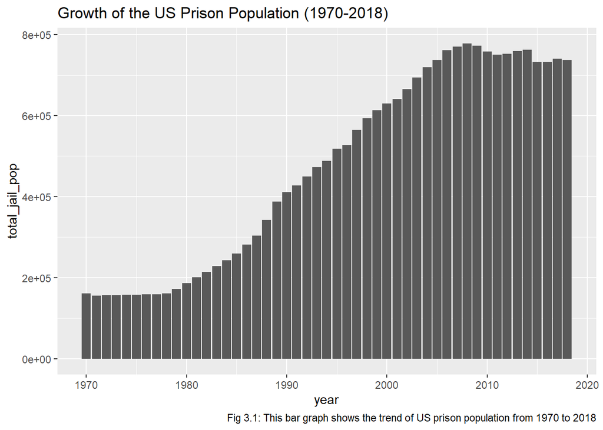

What is the trend in US Prison Population throughout 48 years from 1970 to 2018? Throughout the years, we can see from the bar chart that the total jail population of the US is going up until 2008. The pattern shows the most rapid growth between 1979 and 2008. Before 1979, the jail population was relatively constant and there was a slight decreasing in total jail population between 2008 and 2018.

## Growth of Prison Population by State

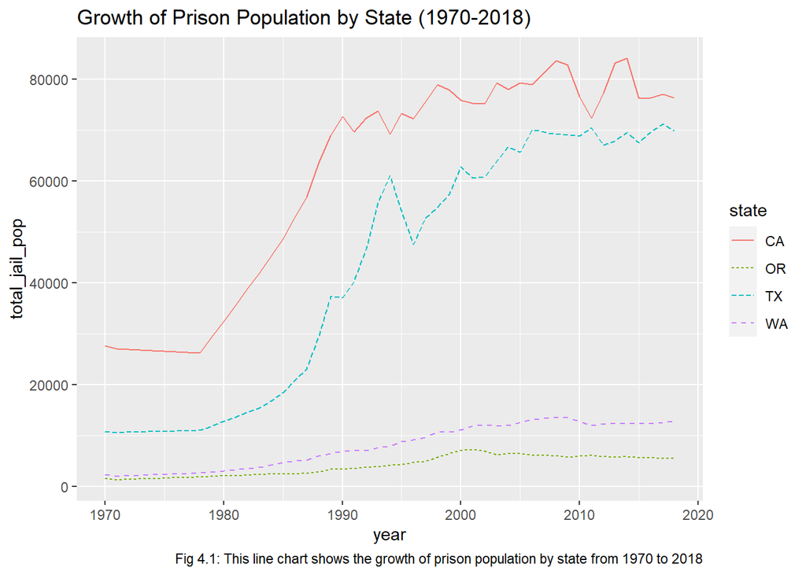

## Jail Population Trend by Gender (Male vs Female)

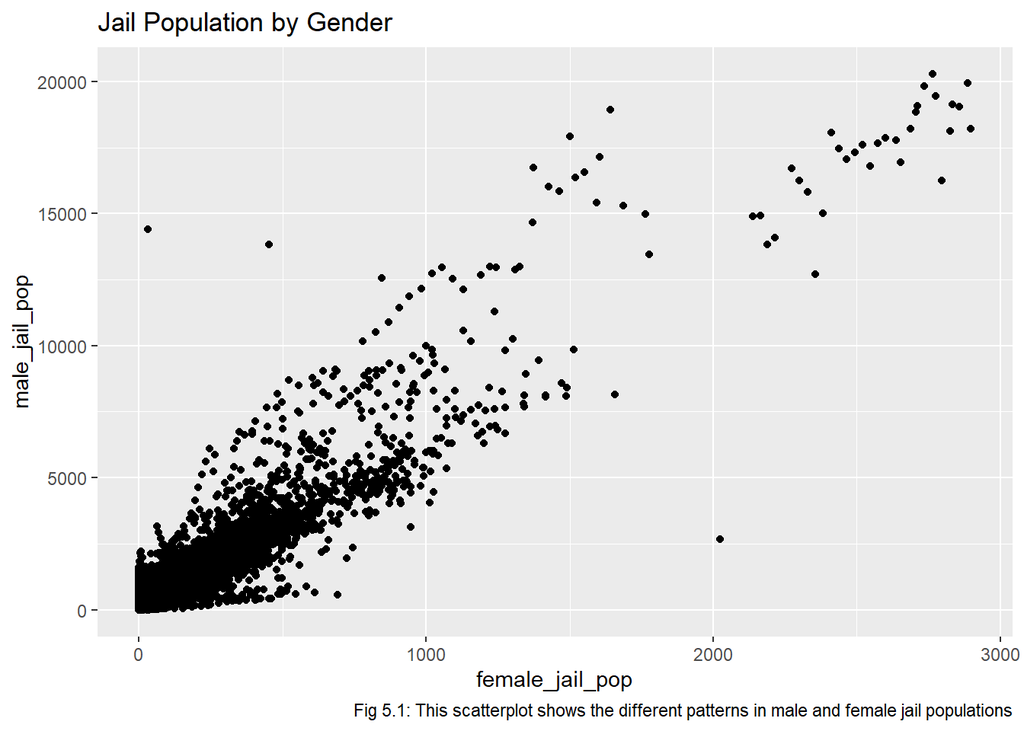

## Jail Population Trend for AAPI and White Population

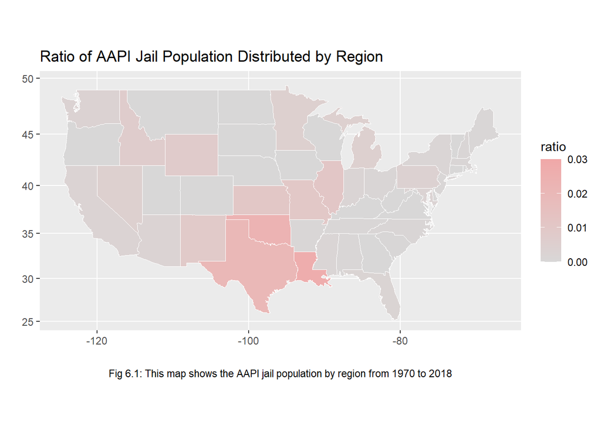

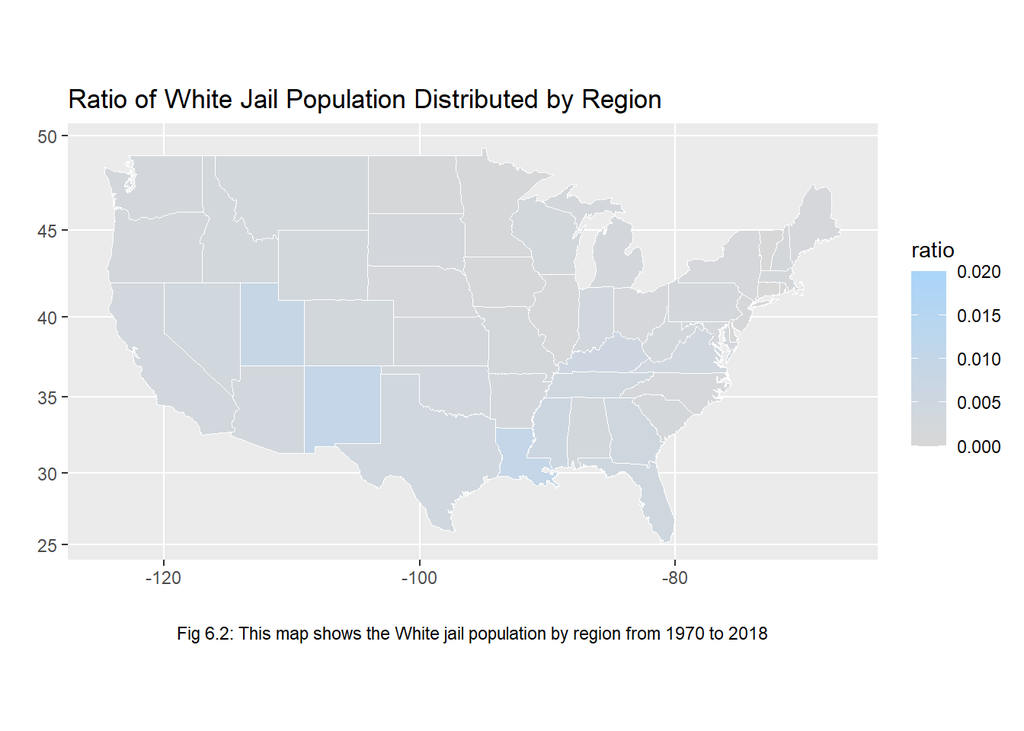

What does the ratio in prison population for White and AAPI populations look like? The map for AAPI shows that there’s a higher ratio of AAPI jail population in the south region and for the central, west, and northwest region, the ratio is not as high as the south region. The east region’s ratio is not that high either. The ratio for the White population shows that there are a higher ratio of White jail population in the eastern region and is especially high in some states in the southern and western regions like New Mexico, Louisiana, and Utah.